# Spatial and Non-Spatial Model Analysis of Buruli ulcer Cases in Ghana

Jake Frattone

March 9, 2017

# Introduction

Buruli ulcer (BU) is an infection caused by *Mycobacterium ulcerans* ( *4* ). The infection usually begins with a harmless looking pimple or rash. When left without treatment the rash flares up and may result in deformities, loss of limbs or organs, and sometimes death ( *1* ). The only treatments currently known for BU are an antibiotic regimen and surgery ( *1* , *4* ). Also the way in which BU is spread is not currently known. It has been hypothesized that BU is a waterborne disease, but we cannot be sure of this. BU is fairly widespread and has been reported in almost 27 countries ( *1* ). Most of the countries that have reported BU cases are in the tropical areas of West Africa. This includes Ghana, our primary area of study for this project.

## Study Area

This project involved 89 districts in Southern Ghana. These 89 districts are located in the regions of Brong Ahafo, Ashanti, Eastern, Greater Accra, Central, and Western. We limited our research to this portion of Ghana because these were the only regions that we have reported Buruli ulcer data on.

# Materials and Methods

## Data Sources

**1. Hospital and Health Center Locations and Population Projections:** The locations for all of the hospital and health center and population projections were found on Harvard’s WorldMap Project website. https://worldmap.harvard.edu/ghana-health/. The data was collected by the Virtue Foundation, a philanthropic institute.

**2. Land Use and Land Cover Satelite Images:** The satellite image used to calculate the land use and land cover data came from ASTER GDEM. This is the Advanced Spaceborne Thermal Emission and Reflection Radiometer (ASTER) Global Digital Elevation Model (GDEM)

*Figure 2. Example of How Land use and Land Cover data is calculated for the District of Botsomtwe/Atwima/Kwanhuma*

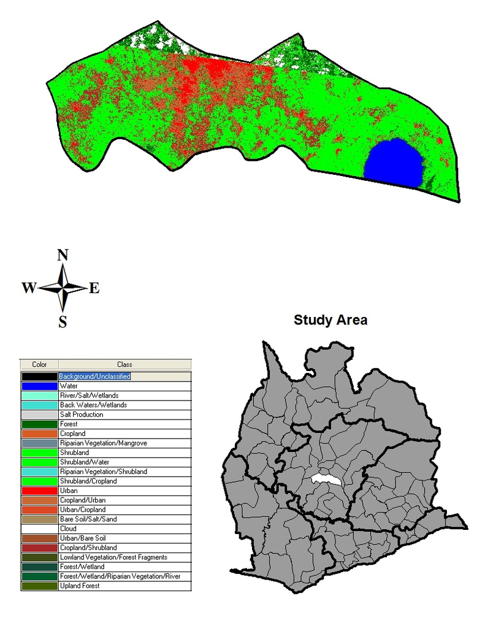

*Table 1. Land Use and Land Cover Percentages of Botsomtwe/Atwima/Kwanhuma District*

| Water | Wetlands | Salt | Forest | Cropland | Riparian | Shrubland | Urban | Sand | Cloud | Background |
| --- | --- | --- | --- | --- | --- | --- | --- | --- | --- | --- |
| 5.37 | 0 | 0 | 4.4 | 26.73 | 0.05 | 57.27 | 4.32 | 0 | 1.87 | 0 |

**where:**  
**WaterPercent** = Water  
**WetlandsPercent** = River/Salt/Wetlands + Back Waters/Wetlands  
**SaltPercent** = Salt Production  
**ForestPercent** = Forest + Lowland Vegetation/Forest + Forest/Wetland + Forest/Wetland/Riparian Vegetation/River + Upland Forest  
**CroplandPercent** = Cropland + Cropland/Urban + Cropland/shrubland  
**RiparianPercent** = Riparian Vegetation/Mangrove + Riparian Vegetation/Shrubland  
**ShrublandPercent** = Shrubland + Shrubland/Water + Shrubland/Cropland  
**UrbanPercent** = Urban + Urban/Cropland + Urban/Bare Soil  
**SandPercent** = Bare Soil/Salt/Sand  
**BackgroundPercent** = Background/Unclassified

All these values were divided by the total area of each district to get the estimated percentage of Land.

**3. The Frequency of Buruli ulcer Cases:** The data on the Buruli ulcer cases came from communities or towns in Ghana that reported occurrences of the disease. It should be noted that there are most likely multiple BU cases that are not reported.

### Potential Explanatory Variables For Model Analysis

1. Population
2. Total Health Facilities
3. Shrubland Percent
4. Water Percent
5. Water Presence
6. Wetlands Percent
7. Salt Percent
8. Forest Percent
9. Cropland Percent
10. Riparian Percent
11. Urban Percent
12. Sand Percent
13. Total Health Centers
14. Total Hospitals

## Model Selection

The model was selected by first fitting the full model with all explanatory variables. The insignificant effects were then dropped from the model using a backword elimination method at the 5% significance level $(\alpha = .05)$. This new model was predicting the total number of BU cases with the predictor variables Shrubland Percent, Total Health Centers, Total Hospitals, and Water Percent. After looking at the residuals for this model we decided to add in an offset variable of the population projections for each district. The offset variable was used to model the rate of BU cases for each district. We also decided to transform the Water Percent, Total Health Centers, and Total Hospitals variables. The Water Percent variable was converted into the Water Presence variable. Where water Presence is 0 if there is no water in the district, and water Presence is 1 if there is water in the district. The Total Health Centers and Total Hospitals variables were added together to create the Total Health Facilities variable. We modified these variables in order to create a more interpretable and parsimonious model. The Akaike Information Criterion (AIC) was also used in the model selection process. The AIC can be used to find the best model by picking the model with the lowest (AIC)

## Analysis Methods

Once the data was collected we implemented a Poisson regression model in order to predict the total number of Buruli ulcer cases from 2002 to 2008. The explanatory variables used in the model were the total number of health facilities, population offset, the percent of shrubland, and an indicator variable for the presence of water in each district.

**Poisson Model** ( *3* ):
$$log(\mu) = \beta_0 + \beta_1x_1 + ... + \beta_kx_k$$
*Where*:

$\mu$ = Average Buruli ulcer Case Rate Per (10,000 People)

After running the Poisson model we were interested in running a Bayesian Car Model as well. Before doing so, a Moran Spatial Autocorrelation test was run to determine if the spatial model would be necessary.

**Moran’s I** ( *3* ):

$$I =
\frac{n\sum_i\sum_jw_{ij}(y_i - \bar{y})(y_j - \bar{y})}
{(\sum_{i \neq j}w_{ij})(y_i - \bar{y})^2}$$

*Where*:

$n$ = total number of observations  
$y_i, y_j$ = Total cases in districts i and j  
$\bar{y}$ = average Total cases of all districts  
$w_{ij}$ = entries of proximity matrix

The Moran spatial autocorrelation statistic ranges from -1 to 1, similiar to the correlation coefficient. A positive Moran’s value signifies positive spatial correlation or clustering between the districts. A negative statistic represents despersion or negative spatial autocorrelation ( *2* ).

If the $y_i$s are independently and identically distributed and have no spatial autocorrelation, then the Moran’s statistic is normally distributed ( *3* ).

$$\mu = \frac{-1}{(n-1)}$$
$$\sigma^2 = \frac{n^2(n-1)S_1 - n(n-1)S_2 - 2S_0^2}{(n+1)(n-1)^2S_0^2}$$
$$S_0 = \sum_{i \neq j}w_{ij}$$
$$S_1 = \frac{1}{2}\sum_{i \neq j}(w_{ij}+w_{ji})^2$$
$$S_2 = \sum_j(\sum_{j}w_{ij} + \sum_iw_{ji})^2$$
$$I \sim N(\mu,\sigma^2)$$
The spatial Bayesian Car Model was used to predict the total number of Buruli Cases from 2002 to 2008. The same explanatory variables were used as in the non-spatial model.

**Spatial Bayesian CAR Model** ( *3* ):

$$Y_k \sim Poisson(\mu_k) = x_k\beta + O_k + \psi_k$$

$$\psi_k = \phi_k + \theta_k$$
$$\phi_k|\phi_{-k}, W, \tau^2 \sim N\left(\frac{\sum_{i=1}^Kw_{ki}\phi_i}{\sum_{i=1}^Kw_{ki}},\frac{\tau^2}{\sum_{i=1}^Kw_{ki}}\right)$$
$$\theta_k \sim N(0,\sigma^2)$$
$$\tau^2, \sigma^2 \sim Inverse-Gamma(a,b)$$

# RESULTS

## Visualizations of Gathered Data

*Figure 3. Total Number of Buruli Ulcer Cases (2002-2008) For Each Ghana District*

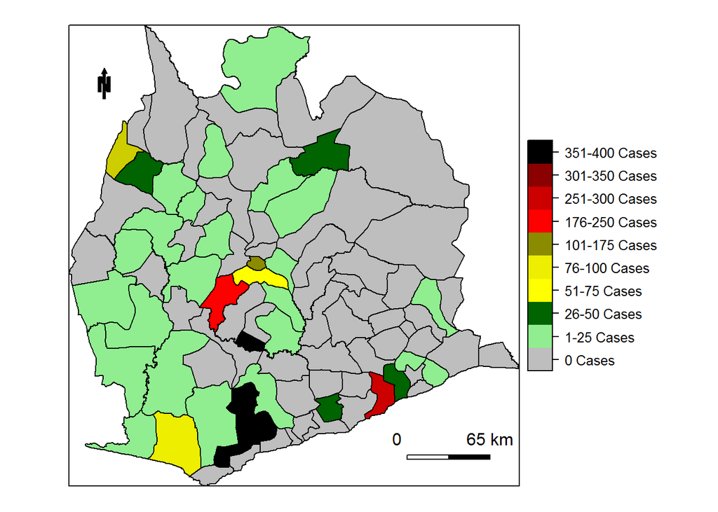

*Figure 4. Ghana Population Projections (2008)*

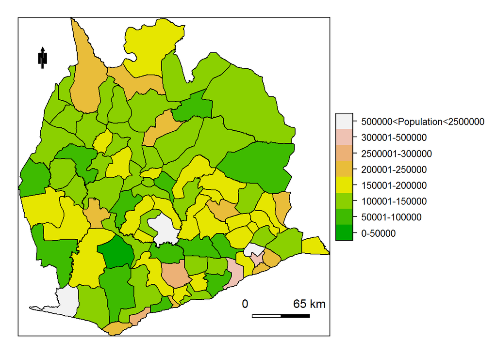

*Figure 5. Ghana Hospital Counts*

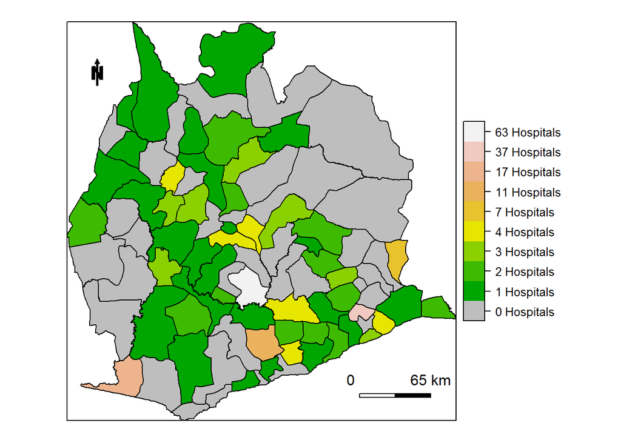

*Figure 6. Ghana Health Center Counts*

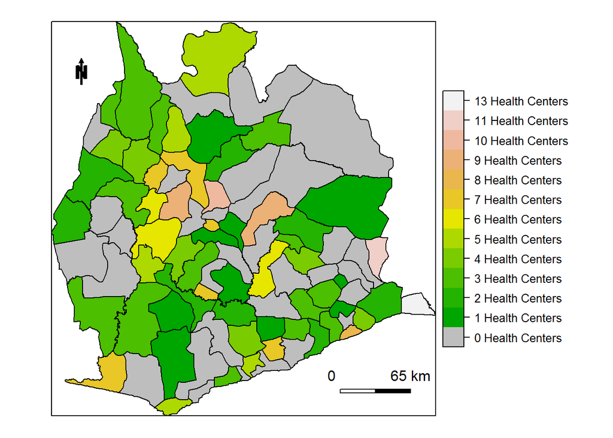

*Figure 7. Ghana Total Health Facilities Counts*

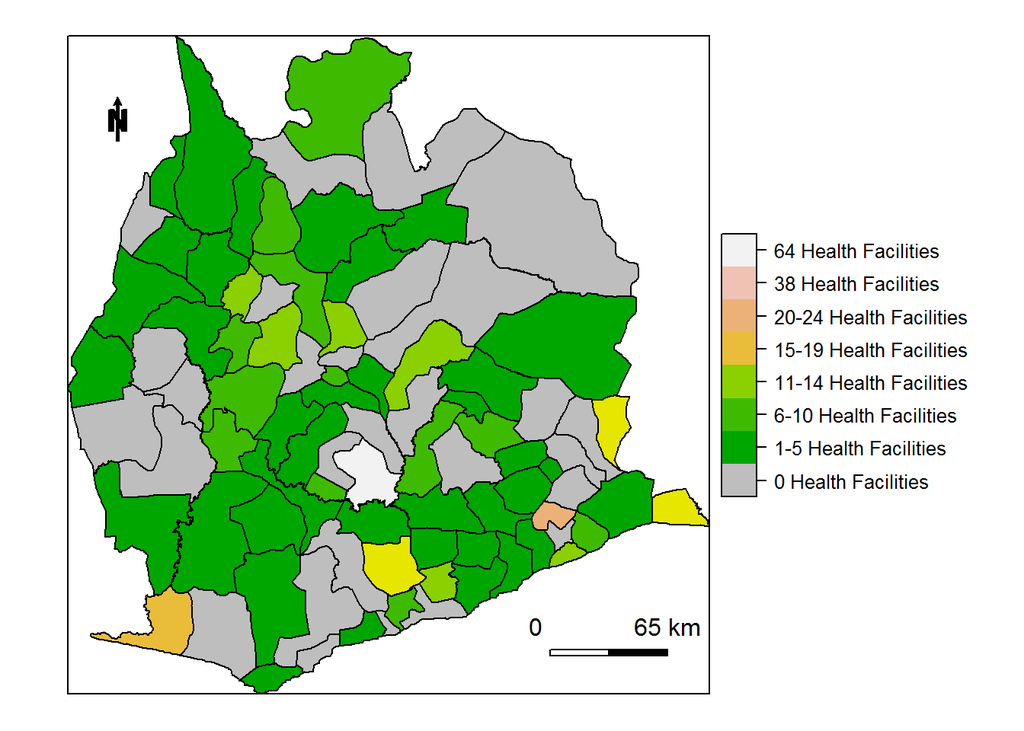

*Figure 8. Histogram of Shrubland Percentages for all Ghana Districts in Study Area*

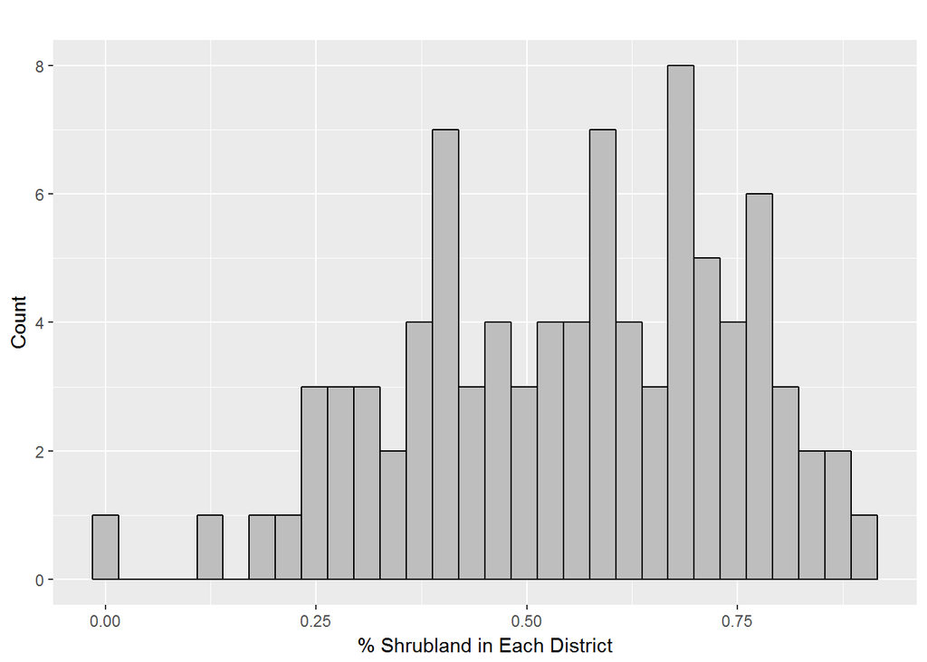

*Figure 9. Histogram of Water Percentages for all Ghana Districts in Study Area*

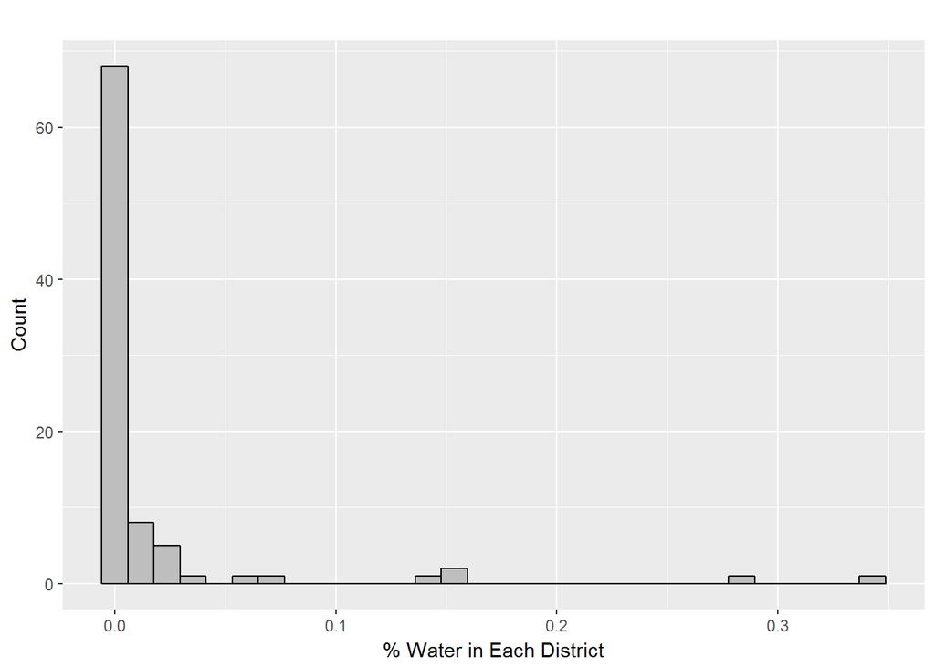

*Figure 10. Water Presence in Each Ghana District*

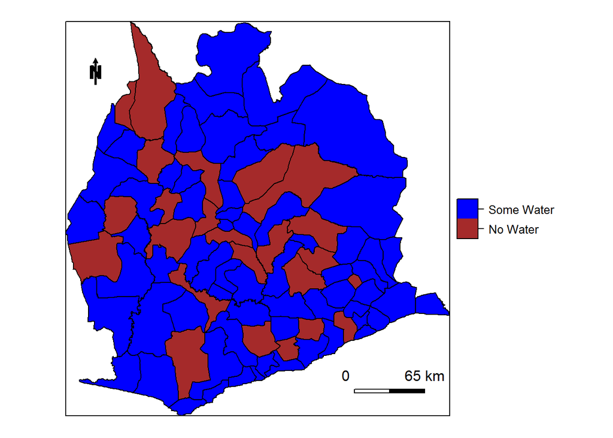

## Non Spatial Model of Total Buruli ulcer Cases

```
##
## Call:
## glm(formula = form, family = poisson(link = log), data = data.combined@data)
##
## Deviance Residuals:
##     Min       1Q   Median       3Q      Max
## -11.992   -7.295   -4.730   -2.624   37.595
##
## Coefficients:
##                           Estimate Std. Error z value Pr(>|z|)
## (Intercept)             -11.295098   0.124169  -90.97   <2e-16 ***
## TotalHealthFacilities    -0.041008   0.002642  -15.52   <2e-16 ***
## ShrublandPercent          2.281339   0.135543   16.83   <2e-16 ***
## WaterPresenceSome Water   1.619110   0.081036   19.98   <2e-16 ***
## ---
## Signif. codes:  0 '***' 0.001 '**' 0.01 '*' 0.05 '.' 0.1 ' ' 1
##
## (Dispersion parameter for poisson family taken to be 1)
##
##     Null deviance: 9486.8  on 88  degrees of freedom
## Residual deviance: 7929.6  on 85  degrees of freedom
## AIC: 8094.2
##
## Number of Fisher Scoring iterations: 7
```

$$log(\mu) = -11.295 + -.041log(x_1) + 2.281log(x_2) + 1.619log(x_3) + log(Population)$$
where:
$\mu$ = Average Buruli ulcer Cases
$x_1$ = Total Health Facilities
$x_2$ = Shrubland Percent
$x_3$ = 1 if there is water and 0 otherwise

## Moran Spatial Autocorrelation Test

$H_0$: No Spatial Autocorrelation  
$H_1$: Positive Spatial Autocorrelation

Positive Spatial Autocorrelation is also known as clustering. This is a relationship where districts with high case counts are near other high case count districts and vice versa ( *2* ).

```
##
##  Monte-Carlo simulation of Moran I
##
## data:  resid.model
## weights: W.list
## number of simulations + 1: 1001
##
## statistic = -0.0060896, observed rank = 565, p-value = 0.4356
## alternative hypothesis: greater
```

$H_0$: No Spatial Autocorrelation  
$H_1$: Negative Spatial Autocorrelation

Negative Spatial Autocorrelation is also called despersion. This is a competitive relationship where districts with high case counts are near districts with low case counts and vice versa ( *2* ).

```
##
##  Monte-Carlo simulation of Moran I
##
## data:  resid.model
## weights: W.list
## number of simulations + 1: 1001
##
## statistic = -0.0060896, observed rank = 538, p-value = 0.5375
## alternative hypothesis: less
```

Since large p-values were calculated for both Moran spatial autocorrelation tests, we would fail to reject the null hypotheses. Therefore it is plausible that there is no spatial autocorrelation ( *2* ).

## Spatial Model 1

```
##
## #################
## #### Model fitted
## #################
## Likelihood model - Poisson (log link function)
## Random effects model - Leroux CAR
## Regression equation - TotalCases ~ TotalHealthFacilities + ShrublandPercent + WaterPresence +
##     offset(log(pop))
## Number of missing observations - 0
##
## ############
## #### Results
## ############
## Posterior quantities and DIC
##
##                           Median     2.5%    97.5% n.sample % accept
## (Intercept)             -18.1045 -18.9071 -17.5751    10000     50.0
## TotalHealthFacilities     0.0163   0.0057   0.0272    10000     50.0
## ShrublandPercent          2.9871   2.3316   3.8131    10000     50.0
## WaterPresenceSome Water   3.1789   2.5749   3.6099    10000     50.0
## tau2                     27.1112  11.9878 117.8423    10000    100.0
## rho                       0.1024   0.0041   0.4862    10000     43.5
##                         n.effective Geweke.diag
## (Intercept)                   128.1        -8.7
## TotalHealthFacilities          37.4         5.3
## ShrublandPercent              137.6         6.7
## WaterPresenceSome Water       459.4         2.1
## tau2                          245.0         1.5
## rho                          2668.6         0.8
##
## DIC =  28203.17       p.d =  -1600.753       LMPL =  -Inf
```

$$log(\mu) = -18.1045 + .0163log(x_1) + 2.9871log(x_2) + 3.1789log(x_3) + log(Population) + SpatialEffects$$
where:
$\mu$ = Average Buruli ulcer Cases
$x_1$ = Total Health Facilities
$x_2$ = Shrubland Percent
$x_3$ = 1 if there is water and 0 otherwise
$Spatial Effects$ = Average effect of neighboring districts on Buruli ulcer case rate

## Residuals for Spatial and Non-Spatial Model 1

*Figure 11. Spatial Model 1 Residuals For Each District*

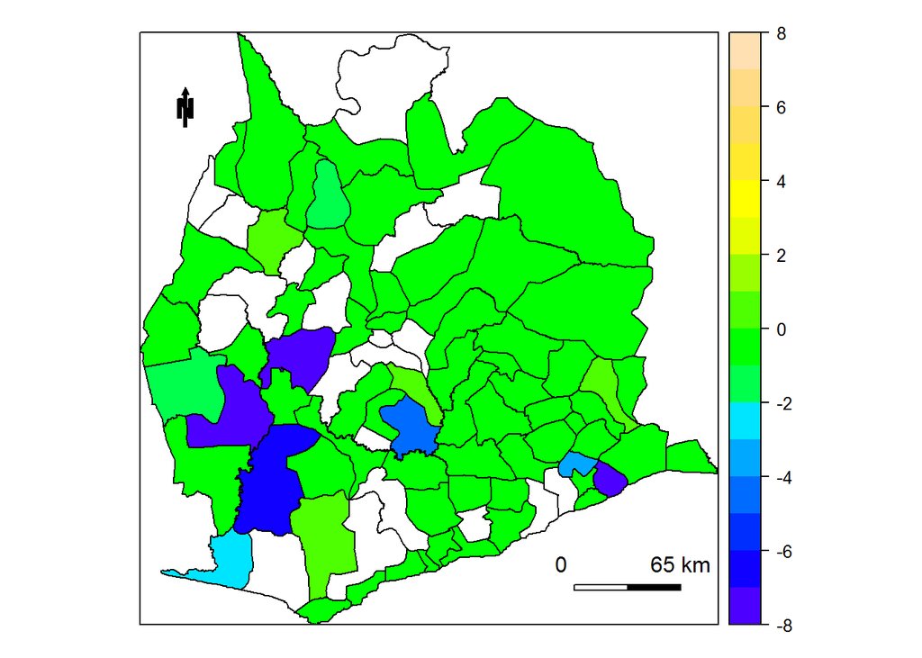

```
##     Min.  1st Qu.   Median     Mean  3rd Qu.     Max.
## -36.5200  -0.2006  -0.1291  51.3300  -0.0552 818.8000
```

*Figure 12. Non-Spatial Model 1 Residuals For Each District*

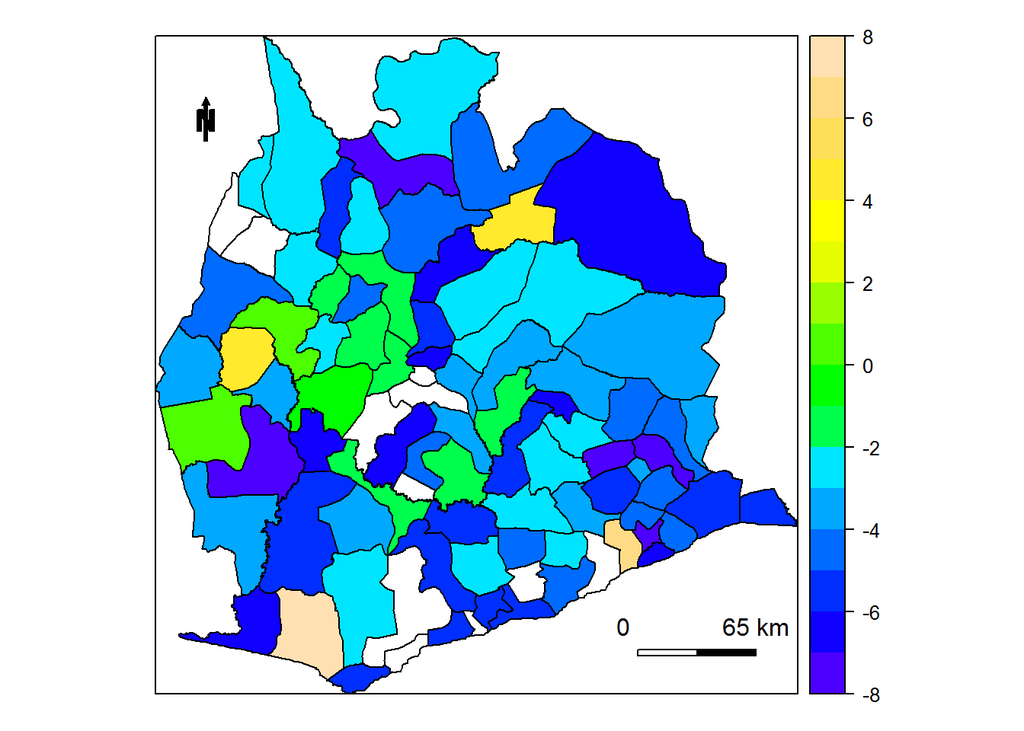

```
##    Min. 1st Qu.  Median    Mean 3rd Qu.    Max.
## -8.4800 -5.1580 -3.3450  0.4055 -1.9140 93.6500
```

Because of these unusual residuals we decided to create a total Buruli ulcer case rate per 10,000 people (Figure 13). We predicted this new variable in the second set of models, instead of the total case counts that we predicted in the first models. We wanted to see if this would lower the extreme variability in the residuals by predicting this new rate instead.

*Figure 13. Histogram of Buruli Ulcer Case Rates For Every 10,000 People*

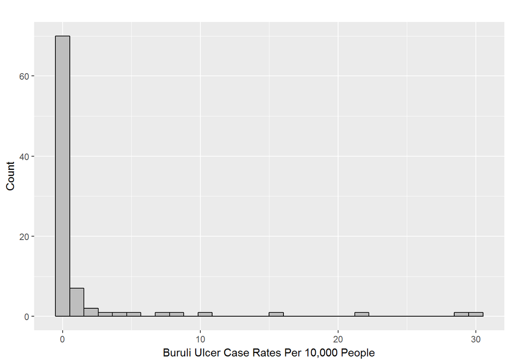

## Non Spatial Model 2 of Buruli ulcer Case Rate per 10,000 people

```
##
## Call:
## glm(formula = form2, family = poisson(link = log), data = data.combined@data)
##
## Deviance Residuals:
##     Min       1Q   Median       3Q      Max
## -2.4387  -2.0811  -1.6001  -0.8318  11.4438
##
## Coefficients:
##                         Estimate Std. Error z value Pr(>|z|)
## (Intercept)             -1.69694    0.45880  -3.699 0.000217 ***
## TotalHealthFacilities   -0.01665    0.01390  -1.198 0.230913
## ShrublandPercent         1.48734    0.48987   3.036 0.002396 **
## WaterPresenceSome Water  1.68658    0.31805   5.303 1.14e-07 ***
## ---
## Signif. codes:  0 '***' 0.001 '**' 0.01 '*' 0.05 '.' 0.1 ' ' 1
##
## (Dispersion parameter for poisson family taken to be 1)
##
##     Null deviance: 628.44  on 88  degrees of freedom
## Residual deviance: 579.75  on 85  degrees of freedom
## AIC: 648.63
##
## Number of Fisher Scoring iterations: 7
```

$$log(\mu) = -1.69694 - .01665log(x_1) + 1.48734log(x_2) + 1.68658log(x_3)$$
where:
$\mu$ = Average Buruli ulcer Case Rate
$x_1$ = Total Health Facilities
$x_2$ = Shrubland Percent
$x_3$ = 1 if there is water and 0 otherwise

## Spatial model 2 of Buruli ulcer Case Rate Per 10,000 People

```
##
## #################
## #### Model fitted
## #################
## Likelihood model - Poisson (log link function)
## Random effects model - Leroux CAR
## Regression equation - RoundedCaseRates ~ ShrublandPercent + WaterPresence
## Number of missing observations - 0
##
## ############
## #### Results
## ############
## Posterior quantities and DIC
##
##                           Median     2.5%    97.5% n.sample % accept
## (Intercept)              -2.0508  -4.2986  -0.3795    10000     49.1
## ShrublandPercent        -10.7260 -12.3753  -8.8988    10000     49.1
## WaterPresenceSome Water  -4.2331  -6.3203  -2.2150    10000     49.1
## tau2                     89.1289  47.8424 226.0993    10000    100.0
## rho                       0.0797   0.0029   0.4339    10000     43.6
##                         n.effective Geweke.diag
## (Intercept)                   172.4        -7.1
## ShrublandPercent              524.4        -2.6
## WaterPresenceSome Water        79.2        13.2
## tau2                         1752.6        -0.4
## rho                          1395.5        -1.8
##
## DIC =  5931.602       p.d =  -117.7163       LMPL =  -2966.162
```

$$log(\mu) = -2.0508 - 10.7260log(x_1) - 4.2331log(x_2) + Spatial Effects$$

where:  
$\mu$ = Average Buruli ulcer Case Rate per 10,000 people  
$x_1$ = Shrubland Percent  
$x_2$ = 1 if there is water and 0 otherwise  
$Spatial Effects$ = Average effect of neighboring districts on Buruli ulcer case rate

## Non Spatial Model 3 of Buruli ulcer Case Rate per 10,000 people

```
##
## Call:
## glm(formula = form3, family = poisson(link = log), data = data.combined@data)
##
## Deviance Residuals:
##     Min       1Q   Median       3Q      Max
## -2.4329  -2.1005  -1.6180  -0.8648  11.5394
##
## Coefficients:
##                         Estimate Std. Error z value Pr(>|z|)
## (Intercept)              -1.8485     0.4472  -4.133 3.58e-05 ***
## ShrublandPercent          1.6183     0.4814   3.362 0.000775 ***
## WaterPresenceSome Water   1.6853     0.3183   5.294 1.20e-07 ***
## ---
## Signif. codes:  0 '***' 0.001 '**' 0.01 '*' 0.05 '.' 0.1 ' ' 1
##
## (Dispersion parameter for poisson family taken to be 1)
##
##     Null deviance: 628.44  on 88  degrees of freedom
## Residual deviance: 581.44  on 86  degrees of freedom
## AIC: 648.32
##
## Number of Fisher Scoring iterations: 7
```

# Conclusion

The data for this study was somewhat limited. For example for many of the districts in our study area we observed values of 0 or missing for the total number of Buruli ulcer cases from 2002-2008. Because of this we thought it would be interesting to use a model to predict the total number of cases for districts that we observed these missing or 0 values. We did this by using the fitted values from a Poisson model that was predicting Buruli ulcer cases rates with water presence and shrubland percent as explanatory variables (Figure 14).

*Figure 14. Predicted Buruli Ulcer Case Rates per 10,000 People for each District*

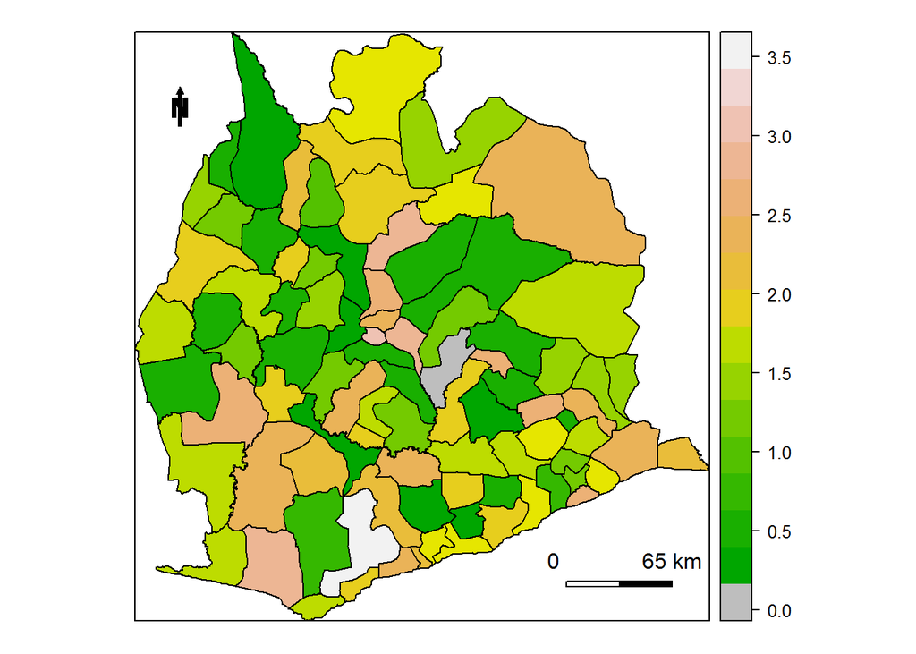

The non-spatial model was preferred over the spatial Bayesian CAR model. Here are some of the reasons why we preferred the non spatial model. First, it was easier to interpret to interpret the non spatial model because it does not have any of the spatial effects in the model. Second, because we failed to reject our Moran’s Spatial autocorrelation tests we do not have an overall spatial autocorrelation relationship between the districts, which is one of the conditions for the Bayesian CAR model. Although there may still be pockets of clustering or dispersion in our study area, we could not detect it with this test. Lastly we observed some extremely unusual residuals in the spatial model. We had residuals as large as 800, when running the spatial model.

We were also interested in the validity of the hypothesis that Buruli ulcer is a waterbourne disease. To do this we checked if there was a statistically significat association between water presence and total Buruli ulcer case rates per 10,000 people in the same model that we used to predict case rates. After looking at this model we found that there was actually a statistically significant association between Water presence and Buruli ulcer case rates (p-value < .0001). Here is an interpretation to describe the relationship between the two variables. We are 95% confident that the Buruli ulcer case rates per 10,000 people for districts with some water are between 3.03 and 10.67 times higher than districts without water, after controlling for shrubland percent. From these results there may worthwhile to look furthur into the possibility that Buruli ulcer is a waterbourne disease.

# References

1. Duker, Alfred A., Alfred Stein, and Martin Hale. “A Statistical Model for Spatial Patterns of Buruli ulcer in the Amansie West District, Ghana.” *International Journal of Applied Earth Observation and Geoinformation* 8.2 (2006): 126-36. Web.
2. “How Spatial Autocorrelation (Global Moran’s I) Works.” ArcGIS Pro. *ESRI*, n.d. Web. 23 May 2017.
3. Huang, Helai, Mohamed Abdel-Aty, and Ali Darwiche. “County-Level Crash Risk Analysis in Florida.” Transportation Research Record: *Journal of the Transportation Research Board 2148* (2010): 27-37. Web.
4. Pileggi, Shannon M., Heather Jordan, Julie A. Clennon, Ellen Whitney, M. Eric Benbow, Richard Merritt, Mollie Mcintosh, Ryan Kimbirauskas, Pamela Small, Daniel Boakye, Charles Quaye, Jiaguo Qi, Lindsay Campbell, Jenni Gronseth, Edwin Ampadu, William Opare, and Lance A. Waller. “Landscape and Environmental Influences on Mycobacterium ulcerans Distribution among Aquatic Sites in Ghana.” *Plos One* 12.4 (2017): n. pag. Web.